# Лабораторнaя работа №5

Настройка рабочей среды

Головина М.И.

Российский университет дружбы народов, Москва, Россия

Факультет Физико-математических и естественных наук

15 марта 2025

# Информация

## Докладчик

- Головина Мария Игоревна
- Бакалавр направления подготовки Математика и механика
- студентка группы НММбд - 02- 24
- Российский университет дружбы народов
- 1132246810@pfur.ru

## Цель

- Приобрести навыки по настройке рабочей среды

## Задание

1. Установить необходимые пакеты для работы с менеджером паролей.
2. Настроить ключ gpg.
3. Инициализировать хранилище.
4. Произвести синхронизацию с git.
5. Настроить интерфейс с броузером.
6. Добавить новый пароль.
7. Заменить существующий пароль.
8. Установить дополнительное программное обеспечение.
9. Установить шрифты.
10. Установить бинарный файл.
11. Создать собственный репозиторий с помощью утилит.
12. Подключить репозиторий к своей системе.
13. Использовать chezmoi на нескольких машинах.
14. Произвести настройку новой машины с помощью одной команды.
15. Настроить ежедневные операции с chezmoi.

# Ход работы

## Установка pass

Я установила pass.

[figure not shown]

## Установка gopass

Я установила gopass

[figure not shown]

## Создание нового ключа gpg

Я создала новый ключ gpg

[figure not shown]

## Создание нового ключа gpg

Я создала новый ключ gpg

[figure not shown]

## Инициализация хранилища

Я инициализировала хранилище

[figure not shown]

## Создание структуры git

Я создала структуру git

[figure not shown]

## Задание адреса репозитория на хостинге

Я задала адрес репозитория на хостинге

[figure not shown]

## Проверка статус синхронизации модно командой

Я проверила статус синхронизации модно командой

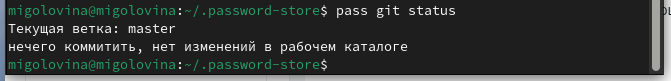

## Устанавка программ

Я устанавила программы

[figure not shown]

## Устанавка программ

Я устанавила программы

[figure not shown]

## Добавление нового пароля

Я добавила новый пароль

[figure not shown]

## Замена существующего пароля

Я заменила существующий пароль

[figure not shown]

## Установка дополнительного программного обеспечения

Я установила дополнительное программное обеспечение

[figure not shown]

## Установка шрифтов

Я установила шрифты

[figure not shown]

## Установка шрифтов

Я установила шрифты

[figure not shown]

## Установка шрифтов

Я установила шрифты

[figure not shown]

## Установка бинарного файла

Я установила бинарный файл

[figure not shown]

## Созданией своего репозитория для конфигурационных файлов на основе шаблона

Я создала свой репозиторий для конфигурационных файлов на основе шаблона

[figure not shown]

## Подключение репозитория к своей системе

Я подключила репозиторий к своей системе

[figure not shown]

## Подключение репозитория к своей системе

Я подключила репозиторий к своей системе

[figure not shown]

## Подключение репозитория к своей системе

Я подключила репозиторий к своей системе

[figure not shown]

## Переход во вторую машину. Использование chezmoi на нескольких машинах

Я перешла во вторую машину и использовала chezmoi на нескольких машинах

[figure not shown]

## Переход во вторую машину. Использование chezmoi на нескольких машинах

Я перешла во вторую машину и использовала chezmoi на нескольких машинах

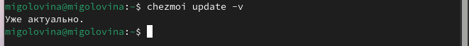

## Настройка новой машины с помощью одной команды

Я настроила новую машину с помощью одной команды

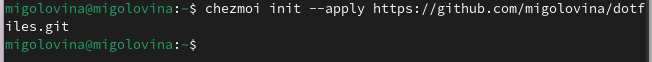

## Ежедневные операции c chezmoi

Я ввела необходимые команды

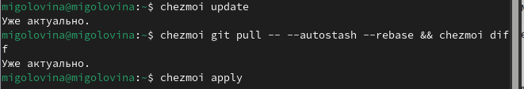

## Ежедневные операции c chezmoi

Я посмотрела нужный файл

[figure not shown]

# Вывод

## Заключение

Я приобрела навыки по настройке рабочей среды.

# Дорогу осилит идущий